# Fatal Motorcycle Crashes

*A sub-analysis of the ARDD focusing on fatal motorcycle crashes.*

Motorcycle riding evokes freedom and exhilaration—but it also carries disproportionate risk. Despite advances in protective gear and rider assist technologies, motorcyclists remain significantly overrepresented in fatal crash statistics across Australia.

This sub-analysis investigates trends in fatal crashes involving motorcyclists and pillion passengers, drawing on over three decades of data. It aims to identify persistent risk patterns by year, state, and rider population, and to assess the relative burden on motorcyclists compared to their licensed population base.

## 1. Key Findings

- **Time and Day Matter (A Lot)** Fatalities peak sharply on Saturdays and Sundays, particularly in the afternoon hours between 1 PM and 5 PM. This aligns with recreational riding patterns, where less experienced or infrequent riders may be pushing limits on unfamiliar or technical roads (“the twisties”).
- **Single-Vehicle vs Multi-Vehicle Crashes*** A sizeable proportion of fatal crashes involve single vehicles, particularly on weekends. This supports the idea that weekend fatalities may disproportionately involve loss of control rather than collision with another vehicle—an angle worth further exploration.
- **Gender Disparity** A staggering 93.7% of fatalities were male, highlighting not just a gendered exposure to risk but perhaps also cultural attitudes toward riding, risk-taking, and safety behaviors.
- **Age Distribution** Fatalities skew young, peaking in the early 20s, then tapering with age—though a surprising number of older riders (60+) are still represented. The age distribution for female fatalities shows a bimodal pattern, possibly reflecting pillion vs rider roles.
- **Seasonal Variation** Fatalities are higher in summer and spring, peaking in March, and lowest in the winter months, especially July. Not exactly surprising—cold rain is a great motivator to leave the bike parked—but the difference is notable.

## 2. Data Cleaning

This notebook is fully self-contained and begins with a structured data cleaning pipeline. The full_clean_pipeline() function (sourced from scripts/data_cleaning.py) performs the following steps:

```
Loads raw crash data from ../data/Crash_Data.csv

Cleans missing or inconsistent entries

Drops incomplete, redundant, or irrelevant columns

Returns a tidy, analysis-ready DataFrame
```

The cleaned dataset is then filtered to isolate fatal incidents involving motorcyclists and pillion passengers, forming the analytical base for this sub-study.

```python
"""
This notebook is fully self-contained and does not depend on the main EDA notebook.

The dataset is loaded and cleaned using `full_clean_pipeline()` from `scripts/data_cleaning.py`, which:
- Loads raw data from /data/Crash_Data.csv
- Cleans missing values and harmonizes variables
- Drops incomplete or irrelevant columns
- Returns a tidy, ready-to-analyze DataFrame
"""

# Set the directory for the script
import sys
sys.path.append("../scripts")

# Importing necessary libraries

import pandas as pd
import numpy as np
import matplotlib.pyplot as plt
import seaborn as sns
from IPython.display import display

from data_cleaning import full_clean_pipeline

df = full_clean_pipeline()

# Create variable for the earliest and latest years in the dataset to be dynamically displayed in plot titles
latest_year = df['Year'].max()
earliest_year = df['Year'].min()
print(f"The dataset contains data from {earliest_year} to {latest_year}.")

# Define constants for reuse
month_names = {1: 'January', 2: 'February', 3: 'March', 4: 'April', 5: 'May',
            6: 'June', 7: 'July', 8: 'August', 9: 'September', 10: 'October',
            11: 'November', 12: 'December'}

month_order = ['January', 'February', 'March', 'April', 'May', 'June', 'July',
            'August', 'September', 'October', 'November', 'December']

day_order = ['Monday', 'Tuesday', 'Wednesday', 'Thursday', 'Friday', 'Saturday', 'Sunday']

custom_palette = {'Female': 'lightcoral', 'Male': 'skyblue'}

# Filter for Motorcyclists and Pillion Passengers
motorcyclist_pillion_fatalities = df[df['Road User'].isin(['Motorcycle rider', 'Motorcycle pillion passenger'])]
motorcyclist_fatalities = df[df['Road User'] == 'Motorcycle rider']
pillion_fatalities = df[df['Road User'] == 'Motorcycle pillion passenger']

# print("\nFiltered DataFrames created:")
# print(f"- motorcyclist_pillion_fatalities: {motorcyclist_pillion_fatalities.shape[0]} rows")
# print(f"- motorcyclist_fatalities: {motorcyclist_fatalities.shape[0]} rows")
# print(f"- pillion_fatalities: {pillion_fatalities.shape[0]} rows")

# # Check for missing values in the filtered DataFrames
# print("\nMissing values in motorcyclist_pillion_fatalities:")
# print(motorcyclist_pillion_fatalities.isnull().sum())
# print("\nMissing values in motorcyclist_fatalities:")
# print(motorcyclist_fatalities.isnull().sum())
# print("\nMissing values in pillion_fatalities:")
# print(pillion_fatalities.isnull().sum())
```

```
The dataset contains data from 1989 to 2021.
```

## 3. Data Visualisation

The following section presents key visualizations that explore how motorcycle-related fatalities have varied over time and by geography. These charts aim to highlight long-term trends, state-level differences, and contextualize deaths relative to the licensed rider population.

### 3.1 Yearly Fatalities

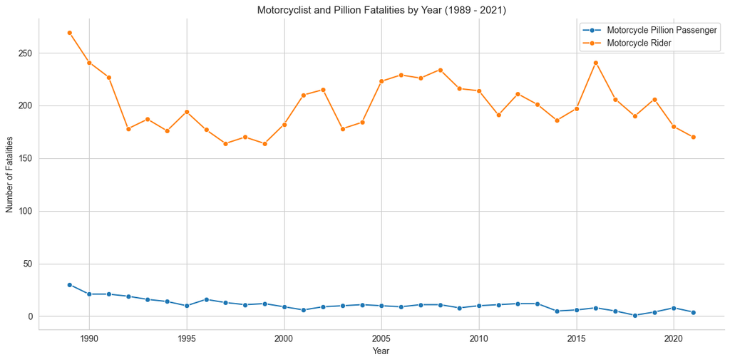

```python
# Group data by Year and Road User for the filtered set
fatalities_by_year_user = motorcyclist_pillion_fatalities.groupby(['Year', 'Road User'])['Crash ID'].count().reset_index(name='Fatalities')

# Capitalize the legend labels
fatalities_by_year_user['Road User'] = fatalities_by_year_user['Road User'].str.title()

# Plotting raw numbers of Fatalities
sns.set_style('whitegrid')
plt.figure(figsize=(12, 6))
sns.lineplot(x='Year',
            y='Fatalities',
            data=fatalities_by_year_user,
            hue='Road User',
            marker="o")
plt.title(f'Motorcyclist and Pillion Fatalities by Year ({earliest_year} - {latest_year})')
plt.xlabel('Year')
plt.ylabel('Number of Fatalities')
plt.grid(True)
sns.despine()
plt.legend(title=None)  # ← Removes legend title
plt.tight_layout()
plt.show()
```

The above line graph shows that the number of motorcycle rider fatalities has not seen a significant decrease over the years, with no obvious trend. While the number of pillion fatalities has remained relatively stable.

However Australia's population has increased substantially since 1989, so a more insightful comparison would be to look at the number of fatalities as a proportion of the number of motorcycle licences. License data from the Bureau of Infrastructure and Transport Research Economics (BITRE) goes back to 2013, so we will use that as our starting point. The following line graph shows the number of fatalities as a proportion of the number of motorcycle licences in Australia.

**Integrating Motorcycle License Data**

To contextualize fatality trends, we incorporated motorcycle licensing data from a BITRE. This dataset required substantial wrangling due to inconsistent formatting and labeling. Key preprocessing steps included:

```
Removing non-data rows

Forward-filling tier labels (Full, Provisional, L Permits)

Reshaping the data to align with crash statistics
```

Despite its structure, this dataset provides valuable insight by allowing normalization of fatalities per licensed rider—offering a more accurate picture of risk over time.

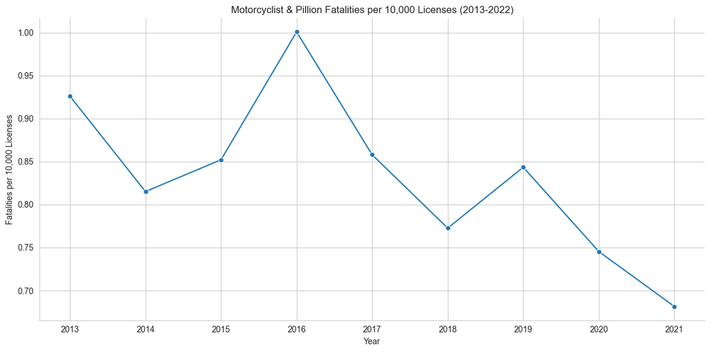

```python
# Fatalities per 10,000 Licenses (2013-2022)

# 1. Calculate total fatalities per year
# Ensure the 'motorcyclist_pillion_fatalities' DataFrame exists and has data
if 'motorcyclist_pillion_fatalities' in locals() and not motorcyclist_pillion_fatalities.empty:
    total_fatalities_per_year = (
        motorcyclist_pillion_fatalities.groupby('Year')['Crash ID']
        .count()
        .reset_index(name='total_fatalities')
    )
else:
    print("Error: 'motorcyclist_pillion_fatalities' DataFrame not found or is empty.")
    total_fatalities_per_year = pd.DataFrame(columns=['Year', 'total_fatalities']) # Avoid downstream errors

# 2. Merge fatality data with license data
# Check if license_summary is not empty before merging
if not license_summary.empty and not total_fatalities_per_year.empty:
    # Ensure 'year' column in license_summary is the same type as 'Year' in total_fatalities_per_year
    license_summary['year'] = license_summary['year'].astype(int) # Ensure integer type for merging
    merged_data = pd.merge(
        total_fatalities_per_year,
        license_summary,
        left_on='Year',
        right_on='year',
        how='inner' # Use inner merge to keep only years present in both datasets
    )
else:
    print("Warning: Cannot merge data as either fatality or license summary is empty.")
    merged_data = pd.DataFrame() # Create empty df

# 3. Filter for the desired year range
if not merged_data.empty:
    start_year_rate = 2013
    end_year_rate = 2022
    merged_data_filtered = merged_data[
        (merged_data['Year'] >= start_year_rate) & (merged_data['Year'] <= end_year_rate)
    ].copy() # Create a copy to avoid SettingWithCopyWarning
else:
    merged_data_filtered = pd.DataFrame() # Create empty df

# 4. Calculate the rate per 10,000 licenses
if not merged_data_filtered.empty and 'total_fatalities' in merged_data_filtered and 'total_motorcycle_licenses' in merged_data_filtered:
    # Avoid division by zero if license count is 0 for a year
    merged_data_filtered['fatalities_per_10k_licenses'] = np.where(
        merged_data_filtered['total_motorcycle_licenses'] > 0,
        (merged_data_filtered['total_fatalities'] / merged_data_filtered['total_motorcycle_licenses']) * 10000,
        0 # Or pd.NA if you prefer
    )
else:
     if not merged_data_filtered.empty:
         merged_data_filtered['fatalities_per_10k_licenses'] = pd.NA # Add column even if empty


# 5. Plot the rate over time
if not merged_data_filtered.empty:
    plt.figure(figsize=(12, 6))
    sns.lineplot(
        x='Year',
        y='fatalities_per_10k_licenses',
        data=merged_data_filtered,
        marker='o'
    )
    plt.title(f'Motorcyclist & Pillion Fatalities per 10,000 Licenses ({start_year_rate}-{end_year_rate})')
    plt.xlabel('Year')
    plt.ylabel('Fatalities per 10,000 Licenses')
    plt.grid(True)
    sns.despine()
    plt.tight_layout()
    plt.show()

#     # Display the calculated rates
#     print(f"\nFatalities per 10,000 Licenses ({start_year_rate}-{end_year_rate}):")
#     print(merged_data_filtered[['Year', 'total_fatalities', 'total_motorcycle_licenses', 'fatalities_per_10k_licenses']])
# else:
#     print("\nNo data available to plot fatalities per 10,000 licenses.")
```

```python
# Load raw stacked CSV, skipping the first row (header) and using no default headers
# Added skipinitialspace=True
df_licenses = pd.read_csv("../data/motorcycle_licenses.csv", header=None, skiprows=1, skipinitialspace=True)

# Define known license tier labels
tiers = ["Full licence", "Provisional licence", "L Permits"]

# Add a column to track the tier label
df_licenses["tier"] = df_licenses[0].where(df_licenses[0].isin(tiers)).ffill()

# Filter out rows that are just the tier labels themselves
df_licenses = df_licenses[~df_licenses[0].isin(tiers)].copy()

# Rename columns based on expected positions
# Col 0 = Date, Col 1 = Car, Col 2 = Motorcycle, etc. (8 numeric cols)
if df_licenses.shape[1] == 9: # 8 original + 1 tier
    df_licenses.columns = ["date", "car", "motorcycle", "light_rigid", "medium_rigid", "heavy_rigid", "heavy_combination", "multi_combination", "tier"]
else:
    print(f"Warning: Unexpected number of columns ({df_licenses.shape[1]}) in license data after adding tier. Check CSV structure.")
    # Handle error or fallback

# Extract the last two digits after the hyphen
two_digit_year = df_licenses["date"].str.extract(r"-(\d{2})$").iloc[:, 0]
# Prepend '20' and convert to numeric (integer), handling potential errors
df_licenses["year"] = pd.to_numeric("20" + two_digit_year, errors='coerce')

# Clean the motorcycle license count column
df_licenses["motorcycle"] = (
    df_licenses["motorcycle"]
    .astype(str)
    .str.replace(",", "", regex=False) # Remove commas (already handled by skipinitialspace, but safe to keep)
    .str.replace(" ", "", regex=False) # Remove spaces within the number string
    .str.strip()
    .replace("", pd.NA)
)

# Convert motorcycle column to numeric, coercing errors to NA
df_licenses["motorcycle"] = pd.to_numeric(df_licenses["motorcycle"], errors="coerce")

# # Debugging block to check the data before dropping NAs
# print("\nLicense data BEFORE dropna:")
# print(df_licenses[['date', 'year', 'motorcycle', 'tier']].head()) # Check extracted year and cleaned motorcycle
# print(df_licenses.info())
# print(f"Shape before dropna: {df_licenses.shape}")

# Drop rows where year extraction failed or motorcycle count is missing/invalid
df_licenses = df_licenses.dropna(subset=["year", "motorcycle"])

# # More debugging to check the data after dropping NAs
# print(f"\nShape AFTER dropna: {df_licenses.shape}")

# Convert year and motorcycle count to integer type now that NAs are handled
if not df_licenses.empty:
    # Convert year first as maybe it was float due to coerce
    df_licenses["year"] = df_licenses["year"].astype(int)
    df_licenses["motorcycle"] = df_licenses["motorcycle"].astype(int)

    # Group by year and sum the motorcycle licenses across all tiers
    license_summary = (
        df_licenses.groupby("year")["motorcycle"]
        .sum()
        .reset_index(name="total_motorcycle_licenses")
    )
else:
    print("Warning: License DataFrame is empty after cleaning and dropping NAs. Cannot create summary.")
    license_summary = pd.DataFrame(columns=["year", "total_motorcycle_licenses"])


# # Display the first few rows of the summary
# print("\nMotorcycle License Summary by Year:")
# print(license_summary.head())

# # Optional: Display the full summary if needed
# print(license_summary)
```

This adjusted measure suggests a gradual decline in fatalities relative to license numbers, particularly since 2016. However, this trend should be interpreted with caution. Unlike car licenses, which are typically held by individuals who drive regularly, motorcycle licenses are often retained even when individuals ride infrequently or not at all. For many, motorcycling is a lifestyle or leisure activity rather than a primary mode of transport. As a result, the number of active, high-frequency riders may be significantly lower than the license count suggests.

Furthermore, the data does not account for changes in road usage patterns, safety equipment adoption (e.g., improved helmets or protective gear), or infrastructure developments that may influence risk exposure. Without granular data on actual riding frequency, distance traveled, or rider demographics, this analysis can only provide a rough indication of risk per license holder—not per rider or per kilometer traveled.

In summary, while the licensing-adjusted fatality rate offers a more nuanced view than raw numbers alone, it remains a limited proxy for exposure and risk. Additional data on active ridership and usage patterns would be needed to draw firmer conclusions about safety trends in the Australian motorcycling community.

### 3.2 Fatalities by State

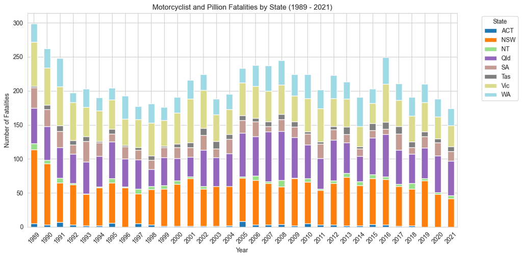

```python
# Group data by Year and State
fatalities_by_year_state = motorcyclist_pillion_fatalities.groupby(['Year', 'State'])['Crash ID'].count().reset_index(name='Fatalities')

# Create a pivot table for the stacked bar chart
pivot_fatalities_state = fatalities_by_year_state.pivot(index='Year', columns='State', values='Fatalities').fillna(0)

# Sort the index to make sure years are in order
pivot_fatalities_state = pivot_fatalities_state.sort_index()

# Plotting stacked bar chart
sns.set_style('whitegrid')
pivot_fatalities_state.plot(kind='bar', stacked=True, figsize=(12, 6), cmap='tab20') # Using a colormap suitable for categorical data
plt.title(f'Motorcyclist and Pillion Fatalities by State ({earliest_year} - {latest_year})')
plt.xlabel('Year')
plt.ylabel('Number of Fatalities')
plt.legend(title='State', bbox_to_anchor=(1.05, 1), loc='upper left') # Adjust legend position
plt.xticks(rotation=45)
plt.tight_layout()
plt.show()
```

The distribution of fatalities largely mirrors population size and urbanisation, with NSW, QLD, VIC, and WA accounting for the bulk of cases. No state appears to significantly over- or under-represented relative to its expected share.

### 3.3 Age Distribution

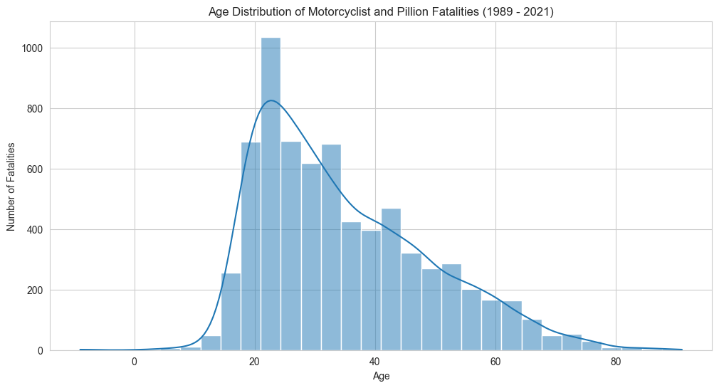

```python
# Plotting the age distribution for motorcyclists and pillion passengers
sns.set_style('whitegrid')
plt.figure(figsize=(12, 6))
sns.histplot(motorcyclist_pillion_fatalities['Age'].dropna(), bins=30, kde=True) # Drop NA values for plotting
plt.title(f'Age Distribution of Motorcyclist and Pillion Fatalities ({earliest_year} - {latest_year})')
plt.xlabel('Age')
plt.ylabel('Number of Fatalities')
plt.grid(True)
plt.show()
```

Fatalities are most common among riders in their 20s, tapering steadily with age. The distribution reflects general traffic fatality trends but drops off earlier — likely because many riders stop riding long before they stop driving.

### 3.4 Gender Breakdown

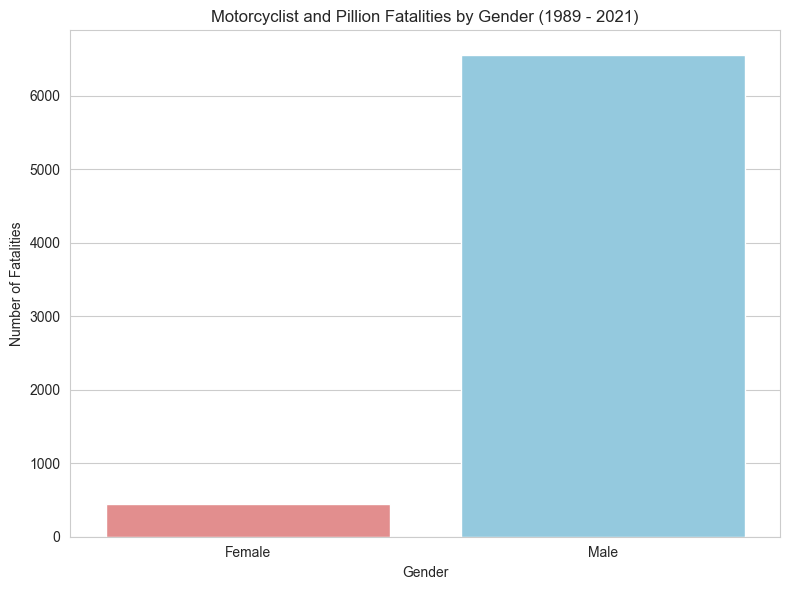

```python
# Filter out missing gender values
gender_fatalities = motorcyclist_pillion_fatalities.dropna(subset=['Gender'])

# Group data by Gender, counting all Crash ID occurrences
gender_count = gender_fatalities.groupby('Gender')['Crash ID'].count().reset_index(name='Fatalities')

# Plotting a bar plot for Gender breakdown
plt.figure(figsize=(8, 6))
sns.barplot(x='Gender', y='Fatalities', data=gender_count, hue='Gender', palette=custom_palette, dodge=False, legend=False)
plt.title(f'Motorcyclist and Pillion Fatalities by Gender ({earliest_year} - {latest_year})')
plt.xlabel('Gender')
plt.ylabel('Number of Fatalities')
plt.tight_layout()
plt.show()

# # Calculate and print the percentage
# gender_count['Percentage'] = (gender_count['Fatalities'] / gender_count['Fatalities'].sum()) * 100
# print("Gender Breakdown (%):")
# print(gender_count[['Gender', 'Percentage']])
```

The overwhelming majority of motorcycle fatalities between 1989 and 2021 involved male riders, who accounted for 93.7% of all deaths. Female riders represented just 6.3% of the total. While this stark imbalance partly reflects the fact that far more men ride motorcycles, it also highlights a broader pattern in risk-taking behavior. Numerous studies have shown that male motorcyclists, particularly younger riders, are more likely to engage in speeding, aggressive cornering, and risky overtaking — all factors linked to crash risk. The gender gap in fatalities is therefore not just about who rides, but often how they ride.

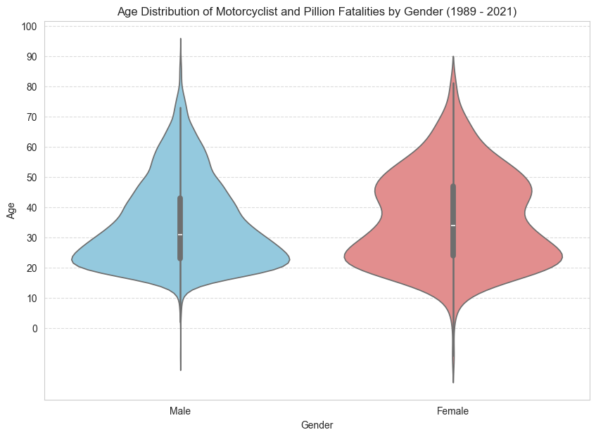

```python
# Filter out missing Age or Gender values for the plot
age_gender_data = motorcyclist_pillion_fatalities.dropna(subset=['Age', 'Gender'])

# Plotting the violin plot
plt.figure(figsize=(10, 7))
sns.violinplot(x='Gender', y='Age', data=age_gender_data, palette=custom_palette, hue='Gender', legend=False)
plt.title(f'Age Distribution of Motorcyclist and Pillion Fatalities by Gender ({earliest_year} - {latest_year})')
plt.xlabel('Gender')
plt.ylabel('Age')
plt.yticks(np.arange(0, 101, 10)) # Set y-ticks from 0 to 100
plt.grid(axis='y', linestyle='--', alpha=0.7)
plt.show()
```

This violin plot shows the age distribution of motorcyclist and pillion fatalities by gender from 1989 to 2021. The distribution for males is skewed younger, with a dense cluster in the 20s and 30s — consistent with the overall age histogram. Female fatalities, while far fewer in number, show a slightly broader age distribution and a marginally higher mean age. The slight double peak among females could hint at two distinct rider or passenger cohorts — perhaps younger pillions and older recreational riders — but given the small sample size, caution is warranted in overinterpreting this pattern. Still, the plot suggests that female riders and passengers involved in fatal crashes tend to be, on average, a bit older than their male counterparts.

### 3.5 Monthly Trends

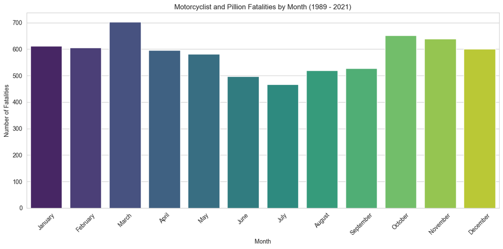

```python
# Map month numbers to names
month_counts_df = motorcyclist_pillion_fatalities.copy() # Use copy to avoid SettingWithCopyWarning if modifying view
month_counts_df['Month Name'] = month_counts_df['Month'].map(month_names)

# Calculate the number of fatalities by month
month_counts = month_counts_df['Month Name'].value_counts().reset_index()
month_counts.columns = ['Month', 'Fatalities']

# Sort the months in calendar order
month_counts['Month'] = pd.Categorical(month_counts['Month'], categories=month_order, ordered=True)
month_counts = month_counts.sort_values('Month')

# Plotting a bar plot for monthly breakdown
plt.figure(figsize=(12, 6))
sns.barplot(x='Month', y='Fatalities', data=month_counts, hue='Month', palette='viridis', dodge=False, legend=False) # Changed palette
plt.title(f'Motorcyclist and Pillion Fatalities by Month ({earliest_year} - {latest_year})')
plt.xlabel('Month')
plt.ylabel('Number of Fatalities')
plt.xticks(rotation=45)
plt.tight_layout()
plt.show()
```

This chart shows the number of motorcyclist and pillion fatalities by month from 1989 to 2021. Unsurprisingly, the colder, wetter winter months of June and July record the fewest fatalities — likely reflecting both reduced riding frequency and more cautious behavior during poor weather. In contrast, fatalities peak during the warmer months, particularly in March, October, and November, when riding conditions are ideal and recreational use spikes.

### 3.7 Time of Day vs Day of Week

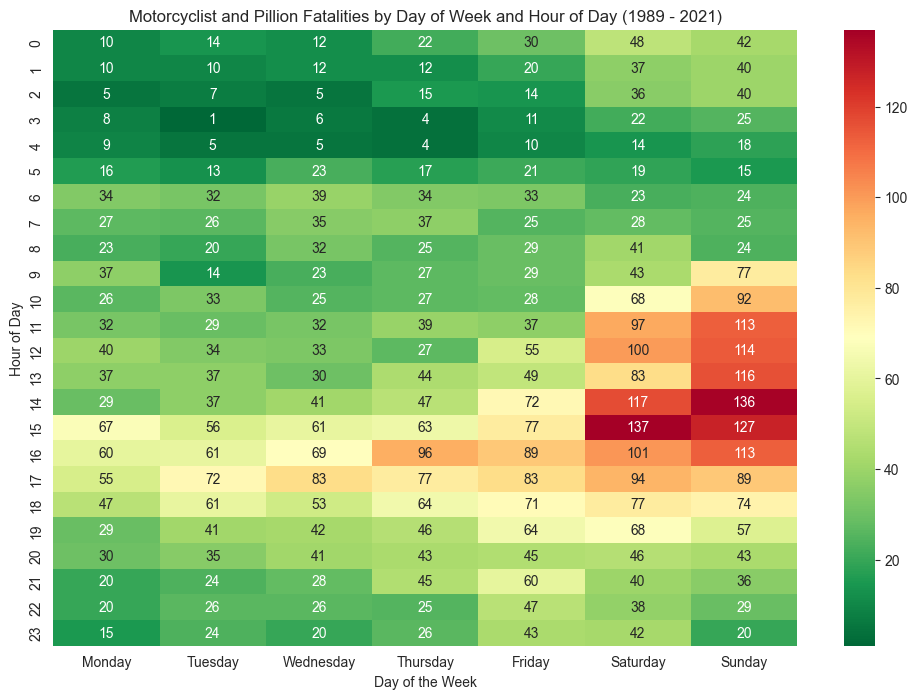

```python
# Select relevant columns and drop missing Time values
heatmap_df = motorcyclist_pillion_fatalities[['Time', 'Dayweek']].dropna(subset=['Time']).copy()

# Extracting the hour from the time field
heatmap_df['Hour'] = heatmap_df['Time'].str.split(':').str[0].astype(int)

# Creating a pivot table
pivot_table = pd.pivot_table(heatmap_df,
                            values='Time',
                            index=['Hour'],
                            columns=['Dayweek'],
                            aggfunc='count',
                            fill_value=0)

# Reindex to ensure all hours and days are present and ordered correctly
pivot_table = pivot_table.reindex(range(24), fill_value=0)
pivot_table = pivot_table.reindex(columns=day_order, fill_value=0) # Use the predefined day_order

# Plotting the heatmap
plt.figure(figsize=(12, 8))
sns.heatmap(pivot_table,
            annot=True,
            cmap='RdYlGn_r', # Reversed Red-Yellow-Green colormap
            fmt='g') # General format for annotations
plt.title(f'Motorcyclist and Pillion Fatalities by Day of Week and Hour of Day ({earliest_year} - {latest_year})')
plt.xlabel('Day of the Week')
plt.ylabel('Hour of Day')
plt.show()

# # Note to self: Do two further plots

# Weekday crashes might skew toward multi-vehicle, likely tied to commuting hours — think lane filtering gone wrong, inattentive drivers during peak traffic, or intersections in city zones.

# Weekend crashes, on the other hand, might lean heavily toward single-vehicle incidents, especially on winding, high-speed rural roads (the twisties). This would back the theory that rider error, overconfidence, or unfamiliarity with terrain plays a major role.
```

This heatmap reveals a striking pattern in motorcycle fatalities by day and hour: the most dangerous time to ride is Saturday and Sunday afternoons, with a particularly sharp spike between 11 a.m. and 4 p.m.. While fatalities occur throughout the week, the clustering on weekends suggests a strong link to recreational riding behavior. Unlike weekday commuters, many weekend riders hit the road less frequently and may lack consistent exposure to high-risk situations. The open roads and “spirited” riding common on weekends can turn deadly — especially on rural or winding routes. In contrast, weekday fatalities are more evenly distributed and may involve commuter riders navigating traffic-heavy environments.

### 3.8 Single vs Multi-Vehicle Crashes

```
Crash Type Breakdown (%):
  Crash Type  Percentage
0   Multiple   57.914286
1     Single   42.085714
```

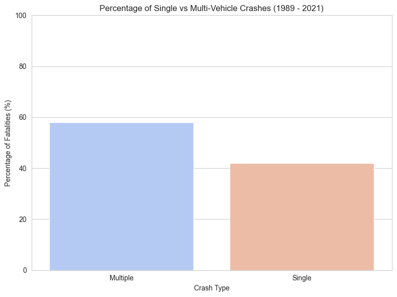

```python
# Calculate counts for each Crash Type
crash_type_counts = motorcyclist_pillion_fatalities['Crash Type'].value_counts().reset_index()
crash_type_counts.columns = ['Crash Type', 'Fatalities']

# Calculate percentages
crash_type_counts['Percentage'] = (crash_type_counts['Fatalities'] / crash_type_counts['Fatalities'].sum()) * 100

# Print the percentages
print("Crash Type Breakdown (%):")
print(crash_type_counts[['Crash Type', 'Percentage']])

# Plotting the bar chart of percentages
plt.figure(figsize=(8, 6))
sns.barplot(x='Crash Type', y='Percentage', data=crash_type_counts, hue='Crash Type', palette='coolwarm', dodge=False, legend=False)
plt.title(f'Percentage of Single vs Multi-Vehicle Crashes ({earliest_year} - {latest_year})')
plt.xlabel('Crash Type')
plt.ylabel('Percentage of Fatalities (%)')
plt.ylim(0, 100) # Set y-axis limit to 100%
plt.tight_layout()
plt.show()
```

Analysis of crash types from 1989 to 2021 reveals that 58% of fatal motorcycle crashes involved another vehicle, while 42% were single-vehicle incidents. This finding highlights that a significant portion of fatalities occur without another party involved, suggesting that rider behavior, decision-making, or road conditions may play an important role.

The high proportion of single-vehicle motorcycle fatalities reinforces a longstanding principle in motorcycle safety: the rider themselves is often the greatest risk factor. While not all single-vehicle crashes stem from rider error, the data implies that many of these tragic events could potentially be mitigated through improved rider training, safer riding practices, and hazard awareness. It also raises questions about infrastructure and road maintenance, both of which disproportionately affect motorcyclists.

In contrast, multi-vehicle crashes remind us that vigilance is equally required around other road users, many of whom may fail to detect or respect motorcyclists. Together, these figures point to the need for both personal responsibility and broader systemic efforts to protect motorcyclists.

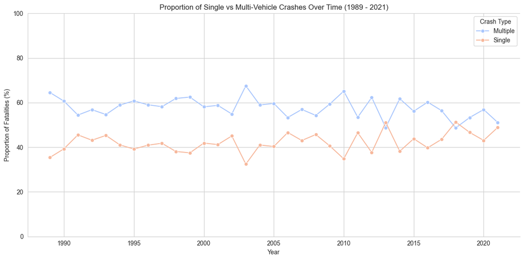

```python
# Line Graph of Proportions Over Time

# Group by Year and Crash Type, count fatalities
fatalities_by_year_crash_type = motorcyclist_pillion_fatalities.groupby(['Year', 'Crash Type'])['Crash ID'].count().reset_index(name='Fatalities')

# Calculate total fatalities per year
total_fatalities_per_year = fatalities_by_year_crash_type.groupby('Year')['Fatalities'].transform('sum')

# Calculate proportion for each crash type per year
fatalities_by_year_crash_type['Proportion'] = (fatalities_by_year_crash_type['Fatalities'] / total_fatalities_per_year) * 100

# Plotting the line graph of proportions
plt.figure(figsize=(12, 6))
sns.lineplot(x='Year',
            y='Proportion',
            data=fatalities_by_year_crash_type,
            hue='Crash Type',
            marker='o',
            palette='coolwarm')
plt.title(f'Proportion of Single vs Multi-Vehicle Crashes Over Time ({earliest_year} - {latest_year})')
plt.xlabel('Year')
plt.ylabel('Proportion of Fatalities (%)')
plt.ylim(0, 100) # Set y-axis limit to 100%
plt.grid(True)
sns.despine()
plt.legend(title='Crash Type')
plt.tight_layout()
plt.show()
```

Modern motorcycles, including mid-range performance bikes, now come equipped with advanced safety features such as traction control, ABS, multiple rider modes, wheelie control, and quickshifters. High-end models even offer lean-angle-sensitive ABS, cornering lights, and ride-by-wire throttles. Simultaneously, protective gear has improved dramatically — with the rise of ECE 22.06-certified helmets, airbag vests, and CE Level 2-rated armor becoming increasingly standard and affordable.

Despite these improvements, the relative rise in single-vehicle fatalities suggests that technology alone is not enough to prevent crashes. These incidents may stem from factors like excessive speed, rider inexperience, or misjudgment on corners and rural roads — scenarios where rider behavior and decision-making remain the dominant risk factors. It reinforces the idea that while safety features can mitigate outcomes, they cannot eliminate the inherent risk of riding. This underscores the ongoing need for rider education, road awareness, and perhaps cultural shifts within the motorcycling community toward valuing defensive riding as much as performance and thrill.

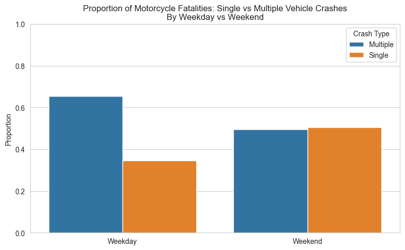

```python
# Step 1: Compute proportions
day_crash_prop = (
    motorcyclist_pillion_fatalities
    .groupby(['Day of week', 'Crash Type'])['Crash ID']
    .count()
    .unstack() # Pivot 'Crash Type' to columns
    .apply(lambda x: x / x.sum(), axis=1) # Calculate proportion across columns (within each 'Day of week')
    .stack() # Convert back to long format
    .rename("Proportion")
    .reset_index()
)

# Step 2: Plot
sns.set_style("whitegrid")
plt.figure(figsize=(8, 5))
sns.barplot(data=day_crash_prop, x='Day of week', y='Proportion', hue='Crash Type')
plt.title('Proportion of Motorcycle Fatalities: Single vs Multiple Vehicle Crashes\nBy Weekday vs Weekend')
plt.ylabel('Proportion')
plt.xlabel('')
plt.ylim(0, 1)
plt.legend(title='Crash Type')
plt.tight_layout()
plt.show()
```

This chart highlights a clear difference in the distribution of motorcycle fatalities between weekdays and weekends. On weekdays, a greater proportion of fatal crashes involve multiple vehicles — likely reflecting commuter traffic and interactions with other road users. On weekends, however, the pattern shifts: single-vehicle crashes slightly outnumber multi-vehicle ones. This supports the theory that recreational riding — often done solo or in smaller groups — carries elevated risk, possibly due to speed, unfamiliar roads, or overconfidence. It suggests targeted interventions for both commuter safety during the week and rider behavior on weekends.

## 4. Conclusion

By integrating external licensing data, we adjusted fatality counts relative to the number of licensed riders—uncovering that risk remains elevated even when accounting for population growth. This suggests that broader safety interventions must be paired with targeted education, skill development, and cultural change within motorcycling communities.

Future work could explore:

```
Linking crash severity to vehicle type or engine capacity

Incorporating weather or road condition data

Analysing post-licensure experience (e.g., L/P plate data where available)
```

Ultimately, these insights can inform more nuanced and evidence-based road safety policies—especially those focused on preventing loss-of-control incidents among recreational riders.